# Raster processing with ‘terra’

# Overview

In this R tutorial, we will explore basic raster processing and analysis in R using `terra` and `tmap` packages. Rasters in GIS are spatial files that consist of a matrix of square cells/pixels structured as rows and columns (a grid) with each pixel representing alocation and a value. Common rasters include aerial photographs, satellite imagery, and digital photos. Raster data can be categorical/discrete or continuous The learning objectives of this tutorial include: importing, reprojecting, and clipping rasters; changing and recategorizing raster data; plotting rasters; and simple raster calculations, statistics, and data extraction. The tutorial is divided into four sections:

1. - Importing
   - Preview
2. - Projecting data
   - Cropping rasters
3. - Zonal statistics
   - Data extraction
4. - Plotting with tmap
   - Colour scale
   - Adding layers

# Getting started with rasters

We begin by first loading relevant packages:

```r
library(tidyverse)     # dplyr, ggplot2, & friends
library(terra)         # Raster processing and analysis
library(sf)            # spatial vector data manipulation
library(tmap)          # Plotting spatial data
library(cowplot)       # panel plots
library(RColorBrewer)  # more colour palettes
library(grid)          # (part of base R) used to create inset map
```

Next, lets import our data and take a first look. We start with the wolf data, which contains point data (10,000 points) from GPS collars on wolves through Alberta and BC

```r
# import wolf location csv
wolf <- read.csv("data/wolf_movement/wolf_crop_sample.csv")
# First three rows of wolf track
head(wolf, 3)
```

```
##        long      lat   ID
## 1 -117.6860 52.37671 J112
## 2 -115.9558 51.77467 B082
## 3 -119.0849 53.83844 W108
```

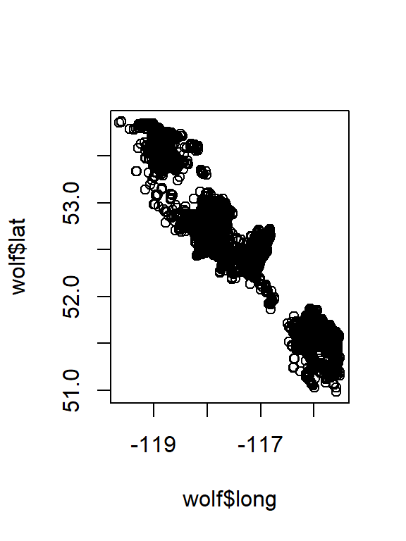

```r
# plot points as long/lat
plot(wolf$long, wolf$lat)
```

Second, we import selected park vector for the Rockies (vector data). This is a vector/polygon layer of 8 parks in the Canadian Rockies. We will import it as a ‘simple feature’ with the `sf` package and as a ‘SpatVector’ using the `terra` package:

```r
#import selected park vector for the Rockies (vector data)
park_sf <- st_read("data/parks_selected")      # read as sf with sf
```

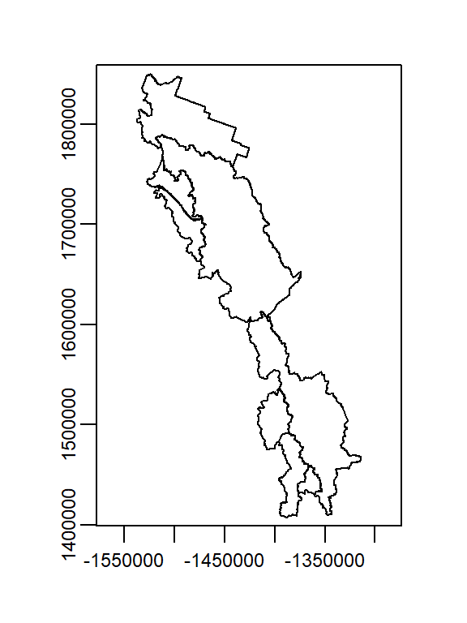

```r
park_rocky <- terra::vect("data/parks_selected")  # read as SpatVector with terra
# plot vector
plot(park_rocky)
```

Third, we import the categorical park raster. This dataset includes all national and provincial parks in the study area as a raster.

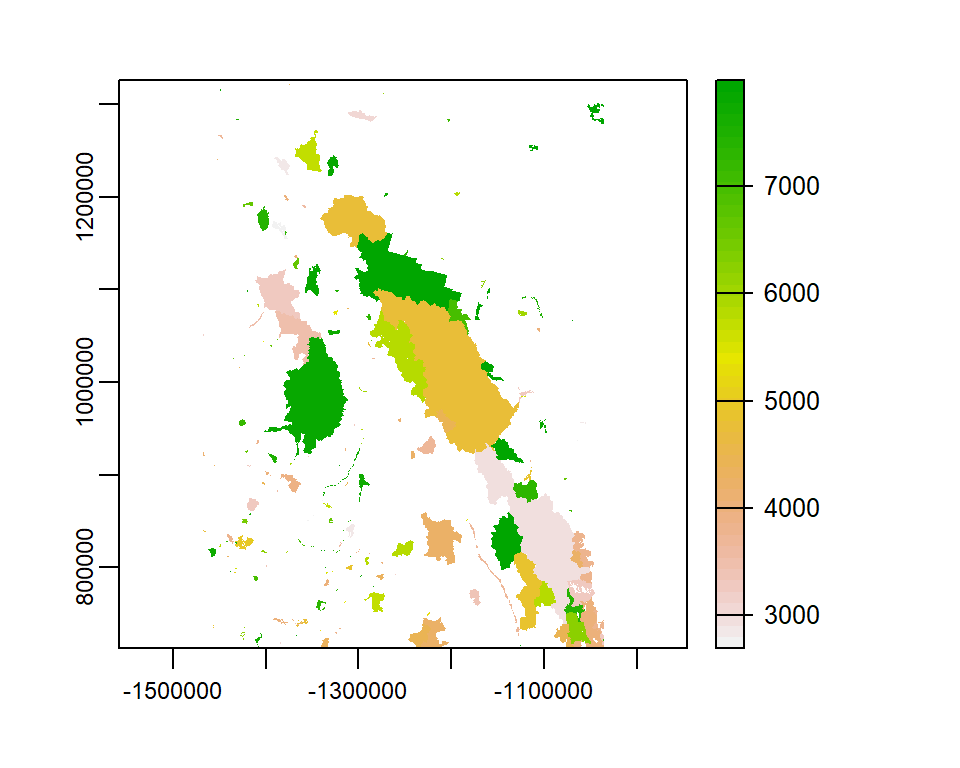

```r
# import categorical rasters
park_cat <- rast("data/parks_id.tif")      # park zones (categorical)
# plot rasters
plot(park_cat)
```

Fourth, we import road and population density rasters. These rasters provide road and population density within 3km buffers around each cell.

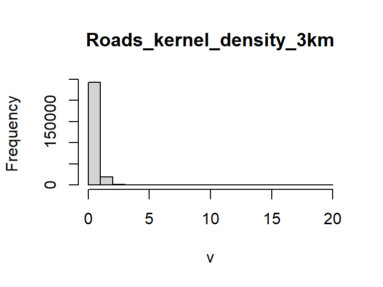

```r
# import continuous rasters
road <- rast("data/road_density_3km.tif")  # road density (continuous)
pop <- rast("data/pop_density_3km.tif")    # population density (continuous)
# take a look at the distribution of the road density data
hist(road)
```

Try plotting the ‘road’ and ‘pop’ rasters using the base-R `plot()` function. Also examine the imported data using `summary()` and `class()` functions.

# Raster processing

Let’s try to crop our road density layer to the extent of our eight selected parks, as that is our area of interest

```r
# crop
road_crop <- crop(road, park_rocky)
```

```
## Error: [crop] extents do not overlap
```

Why didn’t that work? Let’s check the CRS of the files

```r
crs(road) == crs(park_rocky)
```

```
## [1] FALSE
```

We see that the projections of the files aren’t the same. Before we start working with spatial data, we must ensure they have the same coordinate reference system (CRS).

## Defining and projecting data

Let’s take a look at the projections of our data (Note: only show the first three lines is shown):

```r
crs(wolf)
```

```
## [1] NA
```

```r
crs(park_sf)
```

```
## CRS arguments:
##  +proj=lcc +lat_0=40 +lon_0=-96 +lat_1=50 +lat_2=70 +x_0=0 +y_0=0
## +ellps=GRS80 +units=m +no_defs
```

```r
crs(park_rocky) %>% cat()
```

```
## PROJCRS["Lambert_Conformal_Conic",
##     BASEGEOGCRS["GCS_GRS_1980_IUGG_1980",
##         DATUM["D_unknown",
...
```

```r
crs(road) %>% cat()
```

```
## PROJCRS["unnamed",
##     BASEGEOGCRS["WGS 84",
##         DATUM["World Geodetic System 1984",
...
```

(Note: `terra` uses ‘Well-known text’ syntax for its projection, which is clearer when printed with `cat()`, though this is not necessary.)

We see that ‘wolf’ is not projected (CRS = NA), and that ‘road’ (CRS = “Lambert Azimuthal Equal Area”) and ‘park_sf’ (CRS = ‘lcc’ = Lambert conformal conic) have different projections.

First, let’s define the CRS for the wolf tracks:

```r
# define wolf CRS
wolf_sf <- wolf %>%
  st_as_sf(coords = c("long","lat")) %>%  # converts to an sf object
  st_set_crs(4326)  # set the CRS using the 'EPGS' code, which in this case is 4326 (WGS 84)
```

Next, we must reproject everything the same projection. It’s best to avoid reprojecting rasters, as this results in information loss, therefore, we use the projection of the ‘road’ as the reference.

```r
# reproject the sf objects to the crs of road
wolf_sf <- wolf_sf %>%
  st_transform(crs(road))
park_sf <- park_sf %>%
    st_transform(crs(road))
# reproject the park SpatVect and SpatRast to the crs of road
park_rocky <- terra::project(park_rocky, road)
park_cat <- terra::project(park_cat, road)
```

## Cropping spatial data to an extent

cropping will cut out a rectangular part of a raster based on the extent of another raster of vector file. If you want to cut out a part of a raster based on the actual boundaries of polygons (e.g. change raster values outside the polygons to NA), use ‘mask’.

```r
# want to have everything cropped to within the selected parks
road_crop <- crop(road, park_rocky)
pop_crop <- crop(pop, park_rocky)
park_cat_crop <- crop(park_cat, park_rocky)
```

## Other raster processing

what if we also want to have the selected parks as a raster?

```r
park_rocky_rast <- rasterize(park_rocky, road, field="NAME_E")
park_rocky_rast <- crop(park_rocky_rast, park_rocky)
```

let’s replace raster values above certain value with NAs

```r
road_na <- road_crop
road_na[road_na>0.1492] <- NA
```

let’s recategorize the road density raster

```r
road_class <- classify(road_crop, c(0,0.06745, 0.28367, 0.44027, 12.72930), include.lowest = TRUE)
```

# Raster analysis

## basic analysis

We can use basic raster algebra to combine rasters to create new ones. For example, we may be interested in creating a metric of human impact that combines the road and population densities.

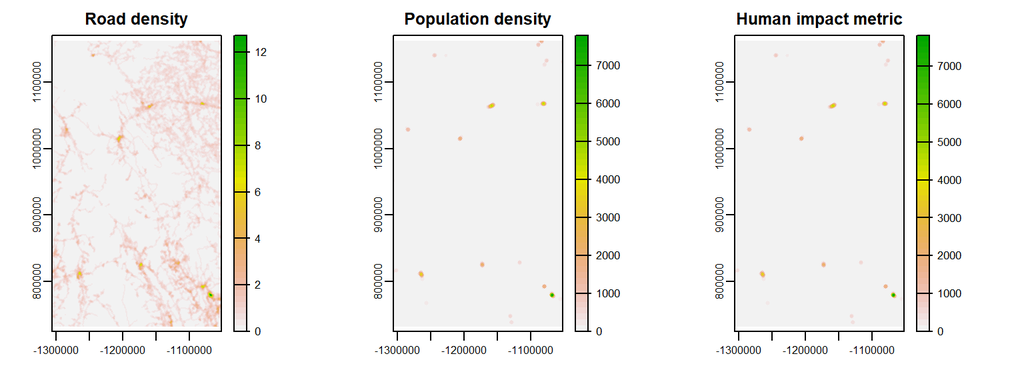

```r
# generate combined raster using basic algebra
dist_comb <- road_crop + pop_crop
# plot the three side-by-side
par(mfrow = c(1, 3))
    plot(road_crop, main = "Road density")  # plot original road
    plot(pop_crop, main = "Population density") # plot original pop
    plot(dist_comb, main = "Human impact metric")  # plot human impact
```

```r
par(mfrow = c(1,1))
```

why doesn’t the new map look much different than our original pop_crop layer? We can see from the scale bars of the first two panels that the scales of the rasters are so different that the pop density layer drives the values in the new raster. What we need to do is put the two rasters on the same scale and combine. We can do this by dividing the road and population values by their respective maximum.

```r
# re-scale road and pop by their respective max
road_rescale <- road_crop/max(values(road_crop))
pop_rescale <- pop_crop/max(values(pop_crop))
```

Now, let’s recreate the new human impact metric and plot it

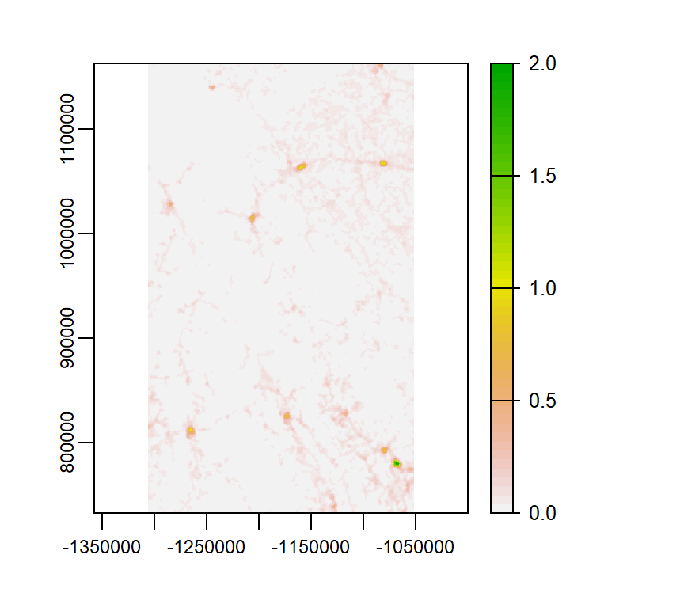

```r
# create new human impact raster
dist_comb <- road_rescale + pop_rescale
# plot
plot(dist_comb)
```

## Analysis by polygon

We might be interested in the average road + pop density for each of our parks of interest

we can calculate this using zonal statistics using our categorical park layer When we rasterized `park_rocky` (a SpatVector), areas outside the polygons were classified as “Not a Number” (`NaN`):

```r
# original values of NAME_E
unique(values(park_rocky_rast$NAME_E))  # includes "NaN"
```

```
##      NAME_E
## [1,]    NaN
## [2,]      5
## [3,]      1
## [4,]      4
## [5,]      0
## [6,]      6
## [7,]      2
## [8,]      3
```

The `zonal()` argument groups these “NaN” cells with the first category in the raster (in our case, “Banff National Park Of Canada”). Note: I do not know why this is the case, it may be a bug in `terra` and `raster`.

```r
# first category in park_rocky_rast
levels(park_rocky_rast)[[1]][1]
```

```
## [1] "Banff National Park Of Canada"
```

We must, therefore, replace “NaN” values with a unique value (I arbitrarily chose 9999)

```r
# replace "NaN" with "NA"
park_rocky_rast[is.nan(park_rocky_rast)] <- 9999
# new values of NAME_E
unique(values(park_rocky_rast$NAME_E))  # "NaN" replaced with "NA"
```

```
##      NAME_E
## [1,]   9999
## [2,]      5
## [3,]      1
## [4,]      4
## [5,]      0
## [6,]      6
## [7,]      2
## [8,]      3
```

Now, we can calculate the zonal statistics. We present three ways of doing it. First, we can use `zonal()`, which takes the value `park_rocky_rast`

```r
# zonal statistics for a categorical raster with 'zonal'
# gets value of dist_comb for each cell
z1 <- raster::zonal(dist_comb, park_rocky_rast, fun = mean, na.rm = T)[,2]
# assign impact values back to raster
park_rocky_rast$impact <- z1[values(park_rocky_rast)+1]
```

Note:`z1` values are indexed from 1, but `park_rocky_rast` is indexed from 0, therefore, we add 1 so the correct value of `z1` is pulled to `park_rocky_rast`. Next we can plot the impact using the `tmap` package. We first call the data to be plotted, then specify that it is a raster and redefine the title, last, we position the legend on the top right.

```
## Legend labels were too wide. The labels have been resized to 0.42, 0.42, 0.42, 0.42, 0.42. Increase legend.width (argument of tm_layout) to make the legend wider and therefore the labels larger.
```

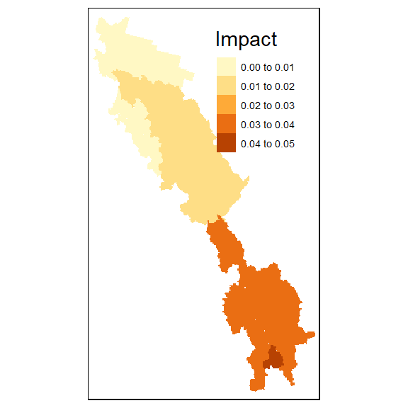

```r
tm_shape(park_rocky_rast$impact) +  # data
  tm_raster(title = "Impact") +     # plot as raster and redefine legend title
  tm_legend(position = c("right", "top"))  # legend position
```

We can achieve a similar result by extracting the values of `dist_comb` by polygon using the `extract()` function. The first argument is again the raster to be summarized, and the second is the polygon, which must be as a class `SpatVector`. However, `tmap` cannot plot `SpatVector`. So we have the option of either extracting with a `SpatVector` then converting it to a `simple feature` or converting a `simple feature` then extracting the values back to the `simple feature`. We’ll do both:

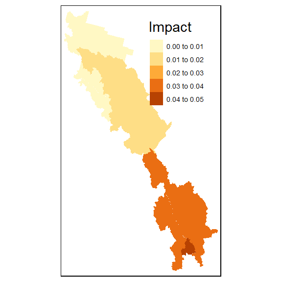

```r
## option 1:
# extract SpatVector polygon with 'extract'
park_rocky$impact <- extract(dist_comb, park_rocky, fun = mean)[,2]
# convert the 'SpatVector' to a 'simple feature' with st_as_sf() then plot
tm_shape(park_rocky %>% st_as_sf())+
  tm_polygons(title = "Impact", col = "impact", border.alpha = 0)
```

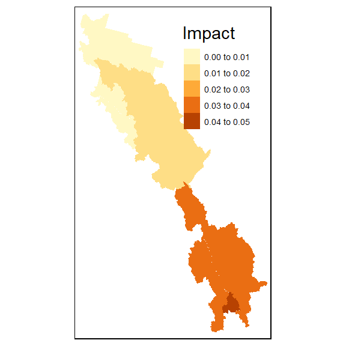

```r
## option 2:
# convert 'simple feature' to 'SpatVector' with vect() then extract
park_sf$impact <- extract(dist_comb, vect(park_sf), fun = mean)[,2]
# plot with 'tmap'
tm_shape(park_sf)+
  tm_polygons(title = "Impact", col = "impact", border.alpha = 0)
```

## Analysis by points

Often, we may be interested in the values of a raster at specific coordinates. For example, we may want to compare the road densities at locations used by wolves to the broader habitat. As with vector polygons, we can extract values using `extract()`, then we assign those back to`wolf_sf` as a new column:

```r
# extract simple
wolf_sf$road_density_simple <- extract(road_crop, vect(wolf_sf))
```

By default, `extract()` pulls the exact value of the cell a point falls within. However, for coarser environmental data, to get a better estimate, we may want to do a weighted average of the four closest cells to each point. For this, we will specify to use the ‘bilinear’ interpolation method:

```r
# extract bilinear
wolf_sf$road_density_bilinear <- extract(road_crop, vect(wolf_sf), method = "bilinear")
```

Just for illustration, we can compare the simple and bilinearly interpolated values by plotting them against each other:

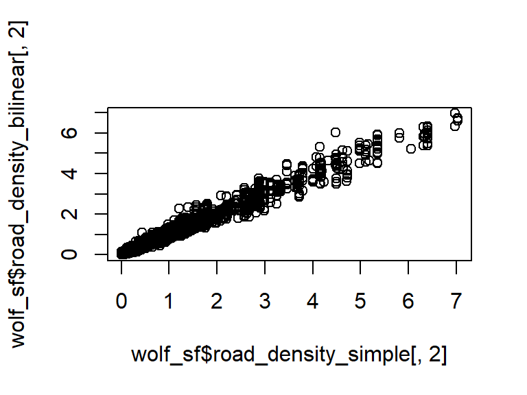

```r
# compare simple and bilinear interpolation
plot(wolf_sf$road_density_simple[,2], wolf_sf$road_density_bilinear[,2])
```

Here, there is a large correlation, likely due to the high resolution of `road_crop`. Now, for some simple “habitat selection” analysis, let’s compare the road densities at the wolf locations with 10,000 random cells across the study area

```r
# number of wolf locations
n <- nrow(wolf_sf)
# sample n = nrow(wolf_sf) locations
road_sample <- sample(values(road_crop), n)
# merge samples
road_data <- rbind(data.frame(sample = "wolf",
                              density = wolf_sf$road_density_bilinear[,2]),
                   data.frame(sample = "random",
                              density = road_sample))
# summarize data
data_summary <- road_data %>%
  group_by(sample) %>%                 # group by sample
  summarise(mean = mean(density),      # calculate mean
            se = sd(density)/sqrt(n))  # calculate SE
```

Let’s make some plots. We’ll plot density on the log-scale since it’s bound by 0 and heavily right-skewed.

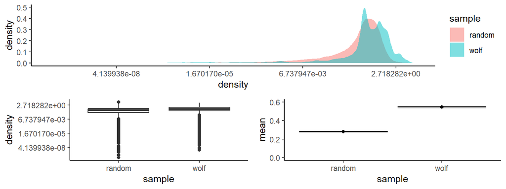

```r
# plot histograms
hist <- ggplot(road_data) +
  geom_density(aes(x = density, fill = sample), alpha = 0.5, col = NA) +
  scale_x_continuous(trans = 'log') +
  theme_classic()
# box plot
box <- ggplot(road_data) +
  geom_boxplot(aes(x = sample, y = density)) +
  scale_y_continuous(trans = 'log') +
  theme_classic()

# mean +/- se
point <- ggplot(data_summary, aes(x = sample, y = mean)) +
  geom_point() +
  geom_errorbar(aes(ymin = mean - se, ymax = mean + se)) +
  scale_y_continuous(limits = c(0, 0.6)) +
  theme_classic()
# merge plots
bottom_plots <- plot_grid(box, point)
plot_grid(hist, bottom_plots, ncol = 1)
```

Last, let’s conduct a (very statistically questionable) t-test

```r
# t-test
test <- t.test(density ~ sample, data = road_data)
test
```

```
##
##  Welch Two Sample t-test
##
## data:  density by sample
## t = -27.819, df = 15269, p-value < 2.2e-16
## alternative hypothesis: true difference in means is not equal to 0
## 95 percent confidence interval:
##  -0.2835669 -0.2462367
## sample estimates:
## mean in group random   mean in group wolf
##            0.2794358            0.5443376
```

According to this, the mean road density occupied by wolves ($\mu_{wolf} = 0.54$) is significantly higher than random samples in the environment ($\mu_{env} = 0.28$; p-value < 0.001, $t_{df = 1.5269\times 10^{4}} = -27.82$).

Try extracting the population density or human impact at the wolf locations. Do these results differ from those of road density?

# Raster plotting

Let’s make a more presentable raster plot of some of this data using tmap with the following layers: 1. As the base layer, we use road density plotted as a raster coloured continuously using the blue-purple colour palette from `RColorBrewer`. 2. The wolf locations points, coloured based on the animal ID (Because there are many individuals, we will hide the legend for wolves). 3. outlines of the parks polygons. 4. We’ll position the road density legend on the bottom left 5. a scale bar 6. a north arrow

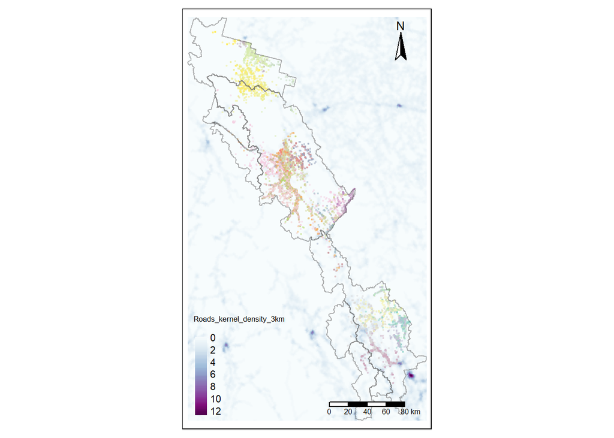

```r
# background road density raster
tm_shape(road_crop) +
    tm_raster(style = "cont", palette = "BuPu") +
  # wolf points coloured by ID and hid legend
  tm_shape(wolf_sf) +
    tm_dots(col = "ID", alpha = 0.3, legend.show = F) +
  # park outline with no fill
  tm_shape(park_sf) +
    tm_polygons(alpha = 0, border.alpha = 0.5) +
  # legend position
  tm_layout(legend.position = c("left", "bottom")) +
  # scale bar
  tm_scale_bar() +
  # north arrow
  tm_compass(position = c("right", "top"))
```

In the above plot, try changing the colour palette used by the wolf ID. Also, the legend title is long - try replacing it with “Road density”. In another plot, try colouring wolf points by road density and polygon fill by mean human impact.